# **NOTE:** Use File > Save a copy in Drive to make a copy before doing anything else

# Project 7: Data Exploration and Visualization

### Overview

In this project, you will apply data exploration and visualization techniques to a real-world dataset of your choice. You'll practice using pandas for data analysis and create meaningful visualizations to gain insights from your data. This project builds on your Python programming skills while introducing you to the exciting world of data science.

In [Lab7](https://colab.research.google.com/drive/15QvSh0csZaCU-OuuPIfpWx5wLDDjmqK4?usp=sharing), you explore the titanic dataset and you should use it as a sample and pick a dataset of your interest to do a similar data exploration and visualization.

### Project Objectives

- Find and select a dataset from a real-world data source
- Formulate a clear inquiry question based on your chosen dataset
- Perform exploratory data analysis using pandas functions
- Create at least two meaningful data visualizations
- Analyze your findings and answer your inquiry question
- Reflect on the insights gained through data exploration

### Data Sources

You can choose from various online data sources such as:

- [Kaggle](https://www.kaggle.com/datasets) - Wide variety of datasets
- [data.gov](https://www.data.gov/) - U.S. government data
- [Our World in Data](https://ourworldindata.org/) - Global development data
- [GitHub](https://github.com/datasets) - Curated datasets
- [Google Dataset Search](https://datasetsearch.research.google.com/) - Search for datasets
- Or any other reliable data source you find interesting

## Part 1: Dataset Selection and Initial Exploration

#### TODO Tasks:

1. Select Your Dataset: Choose a dataset that interests you. Make sure it has at least 100 rows and multiple columns with different data types (e.g., numerical, categorical, dates).

Please create either text or code cells in between the TODO tasks to do the work.

**Retail Sales Data set of Alcohol and Liquor**

2. Import Libraries: Import the necessary libraries (pandas, matplotlib, seaborn) at the beginning of your notebook by creating code cells below this text cell.

```python
!pip install pandas==2.2.2
!pip install seaborn==0.13.2
```

3. Load Your Data: Load your chosen dataset using pandas and save it to a pandas dataframe. Please create a code cell below this text cell to do it.

```python
# Import the pandas library and assign it the alias 'pd'.
# Pandas is a fundamental library for data manipulation and analysis in Python.
import pandas as pd

# Use the read_csv() function from the pandas library to load data from a CSV file.
# The string argument "/content/Warehouse_and_Retail_Sales.csv" is the path to the CSV file.
# The data from this file is then stored in a pandas DataFrame object.
# We assign this DataFrame to a variable named 'retail_df'.
retail_df = pd.read_csv("/content/Warehouse_and_Retail_Sales.csv")
```

```python
from google.colab import drive
drive.mount('/content/drive')
```

4. Data Summary: Use the following functions to do inital exploration your dataset:
- info() - Display information about the dataset structure
- describe() - Show statistical summary of numerical columns
- head() - Display the first 5 rows (df.head())
- shape - Show the dimensions of the dataset (e.g. df.shape)
- columns - Get the column names (e.g. df.columns)

You may use 5 code cells below this text cell to accomplish it.

```python
# Call the info() method on the retail_df DataFrame.
# This method provides a concise summary of the DataFrame.
# It will display information about the index dtype and columns,
# including non-null values and memory usage.
# This is a quick way to get an overview of the dataset's structure and identify missing data.
retail_df.info()
```

```
<class 'pandas.core.frame.DataFrame'>
RangeIndex: 307645 entries, 0 to 307644
Data columns (total 9 columns):
 #   Column            Non-Null Count   Dtype
---  ------            --------------   -----
 0   YEAR              307645 non-null  int64
 1   MONTH             307645 non-null  int64
 2   SUPPLIER          307478 non-null  object
 3   ITEM CODE         307645 non-null  object
 4   ITEM DESCRIPTION  307645 non-null  object
 5   ITEM TYPE         307644 non-null  object
 6   RETAIL SALES      307642 non-null  float64
 7   RETAIL TRANSFERS  307645 non-null  float64
 8   WAREHOUSE SALES   307645 non-null  float64
dtypes: float64(3), int64(2), object(4)
memory usage: 21.1+ MB
```

```python
# Call the describe() method on the retail_df DataFrame.
# This method generates descriptive statistics for the numerical columns.
# It provides insights into the central tendency, dispersion, and shape of the distribution.
# The output typically includes count, mean, standard deviation, minimum,
# maximum, and quartile values (25th, 50th, and 75th percentiles).
retail_df.describe()
```

|  | YEAR | MONTH | RETAIL SALES | RETAIL TRANSFERS | WAREHOUSE SALES |
| --- | --- | --- | --- | --- | --- |
| count | 307645.000000 | 307645.000000 | 307642.000000 | 307645.000000 | 307645.000000 |
| mean | 2018.438525 | 6.423862 | 7.024071 | 6.936465 | 25.294597 |
| std | 1.083061 | 3.461812 | 30.986238 | 30.237195 | 249.916798 |
| min | 2017.000000 | 1.000000 | -6.490000 | -38.490000 | -7800.000000 |
| 25% | 2017.000000 | 3.000000 | 0.000000 | 0.000000 | 0.000000 |
| 50% | 2019.000000 | 7.000000 | 0.320000 | 0.000000 | 1.000000 |
| 75% | 2019.000000 | 9.000000 | 3.267500 | 3.000000 | 5.000000 |
| max | 2020.000000 | 12.000000 | 2739.000000 | 1990.830000 | 18317.000000 |

```python
# Access the 'head()' method of the pandas DataFrame 'retail_df'.
# The head() method is used to display the first n rows of the DataFrame.
# By default, if no argument is provided, it returns the first 5 rows.
# This is a quick way to inspect the data and see the column names and the types of values.
retail_df.head()
```

|  | YEAR | MONTH | SUPPLIER | ITEM CODE | ITEM DESCRIPTION | ITEM TYPE | RETAIL SALES | RETAIL TRANSFERS | WAREHOUSE SALES |
| --- | --- | --- | --- | --- | --- | --- | --- | --- | --- |
| 0 | 2020 | 1 | REPUBLIC NATIONAL DISTRIBUTING CO | 100009 | BOOTLEG RED - 750ML | WINE | 0.00 | 0.0 | 2.0 |
| 1 | 2020 | 1 | PWSWN INC | 100024 | MOMENT DE PLAISIR - 750ML | WINE | 0.00 | 1.0 | 4.0 |
| 2 | 2020 | 1 | RELIABLE CHURCHILL LLLP | 1001 | S SMITH ORGANIC PEAR CIDER - 18.7OZ | BEER | 0.00 | 0.0 | 1.0 |
| 3 | 2020 | 1 | LANTERNA DISTRIBUTORS INC | 100145 | SCHLINK HAUS KABINETT - 750ML | WINE | 0.00 | 0.0 | 1.0 |
| 4 | 2020 | 1 | DIONYSOS IMPORTS INC | 100293 | SANTORINI GAVALA WHITE - 750ML | WINE | 0.82 | 0.0 | 0.0 |

```python
# Access the 'shape' attribute of the pandas DataFrame 'retail_df'.
# This attribute returns a tuple representing the dimensionality of the DataFrame.
# The tuple contains the number of rows and the number of columns, in that order.
retail_df.shape
```

```
(307645, 9)
```

```python
# Access the 'columns' attribute of the pandas DataFrame 'retail_df'.
# This attribute returns an Index object containing the names of all columns.
retail_df.columns
```

```
Index(['YEAR', 'MONTH', 'SUPPLIER', 'ITEM CODE', 'ITEM DESCRIPTION',
       'ITEM TYPE', 'RETAIL SALES', 'RETAIL TRANSFERS', 'WAREHOUSE SALES'],
      dtype='object')
```

5. Inquiry Question: Write a clear, specific question that you want to answer using your dataset by creating a text cell below and **write the question in bold please.**

For example:

- "How has the average temperature changed in major cities over the past decade?"
- "What factors are most strongly correlated with housing prices?"
- "Is there a relationship between education level and income?"

**What item types were the top 5 in retail sales.**

## Part 2: Data Visualization and Analysis

#### TODO Tasks:

1. Data Cleaning (if necessary): Check for and handle any missing values, duplicates, or data quality issues.

**NOTE: This could be a daunting task even for seasoned data scientists. My suggestion is to use a dataset that is already clean if you can for the purpose of completing this assignment in a week.**

```python
# Check for missing values in each column of the DataFrame.
# isnull() returns a boolean DataFrame with True for missing values (NaN) and False otherwise.
# sum() then counts the number of True values (missing values) for each column.
retail_df.isnull().sum()
```

[output not shown]

**dtype:** int64

Examples:

- Checking for missing values: df.isnull().sum()
- Dropping rows with any missing values: df.dropna(inplace=True)
- Dropping columns with all missing values: df.dropna(axis=1, how='all', inplace=True)
- Removing duplicate row: df.drop_duplicates(inplace=True)

```python
# prompt: Dropping rows with any missing values: df.dropna(inplace=True)

retail_df.dropna(inplace=True)
```

```python
# Check for missing values in each column of the DataFrame.
# isnull() returns a boolean DataFrame with True for missing values (NaN) and False otherwise.
# sum() then counts the number of True values (missing values) for each column.
retail_df.isnull().sum()
```

|  | 0 |
| --- | --- |
| YEAR | 0 |
| MONTH | 0 |
| SUPPLIER | 0 |
| ITEM CODE | 0 |
| ITEM DESCRIPTION | 0 |
| ITEM TYPE | 0 |
| RETAIL SALES | 0 |
| RETAIL TRANSFERS | 0 |
| WAREHOUSE SALES | 0 |

**dtype:** int64

2. Create Visualizations: Create at least 2 different types of visualizations that help answer your research question. Choose from:
- Bar charts
- Line plots
- Scatter plots
- Histograms
- Box plots
- Heatmaps
- Any other appropriate visualization

```
Index(['YEAR', 'MONTH', 'SUPPLIER', 'ITEM CODE', 'ITEM DESCRIPTION',
       'ITEM TYPE', 'RETAIL SALES', 'RETAIL TRANSFERS', 'WAREHOUSE SALES'],
      dtype='object')
```

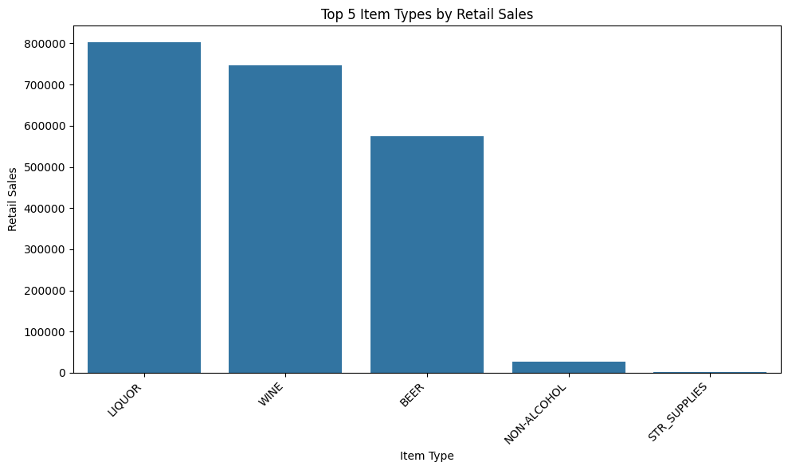

```python
# prompt: write a code for a bar chart using item type as the x axis and retail sales as the y axis

import matplotlib.pyplot as plt
import seaborn as sns

# Check the column names after dropping rows with missing values
print(retail_df.columns)

# Assuming the correct column name is identified from the print output,
# replace 'Item Type' with the actual column name.
# For example, if the correct column is 'Item_Type', the line would be:
# retail_sales_by_item = retail_df.groupby('Item_Type')['Retail Sales'].sum().reset_index()

# Group by the correct item type column and sum 'Retail Sales'
# Replace 'Item Type' with the actual column name from the print output
retail_sales_by_item = retail_df.groupby('ITEM TYPE')['RETAIL SALES'].sum().reset_index()


# Sort by retail sales in descending order and take the top 5
top_5_items = retail_sales_by_item.sort_values(by='RETAIL SALES', ascending=False).head(5)

# Create a bar chart
plt.figure(figsize=(10, 6))
# Replace 'Item Type' with the actual column name from the print output
sns.barplot(x='ITEM TYPE', y='RETAIL SALES', data=top_5_items)
plt.title('Top 5 Item Types by Retail Sales')
plt.xlabel('Item Type') # Replace 'Item Type' with the actual column name
plt.ylabel('Retail Sales')
plt.xticks(rotation=45, ha='right')
plt.tight_layout()
plt.show()
```

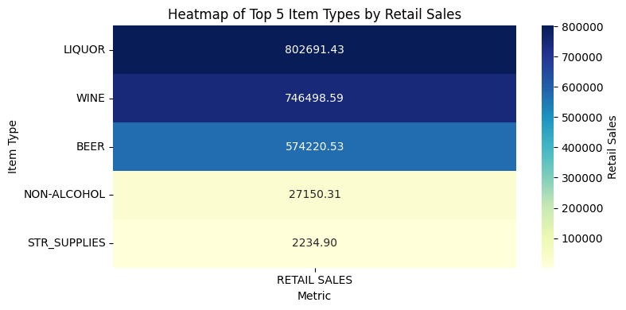

```python
# prompt: Write a code plotting a heat map of the top 5 ITEM TYPE and their RETAIL SALES

# Reshape the data for the heatmap
# The heatmap function expects the data to be structured
# so that the categories you want on the y-axis (Item Type)
# are the index and the categories on the x-axis (in this case, the single metric 'Retail Sales')
# are the columns.
heatmap_data = top_5_items.set_index('ITEM TYPE')

# Create a heatmap
# Set the size of the figure for better readability
plt.figure(figsize=(8, 4))

# Generate the heatmap using the seaborn library
sns.heatmap(
    heatmap_data,          # The data to plot (top 5 items with Item Type as index)
    annot=True,            # Display the data values in each cell of the heatmap
    fmt='.2f',             # Format the annotations to two decimal places
    cmap='YlGnBu',         # Set the color map (Yellow-Green-Blue) to visualize intensity
    cbar_kws={'label': 'Retail Sales'} # Add a color bar and label it
)

# Add a title to the heatmap
plt.title('Heatmap of Top 5 Item Types by Retail Sales')

# Label the x-axis (in this case, it represents the single metric 'Retail Sales')
plt.xlabel('Metric')

# Label the y-axis (these are the Item Types)
plt.ylabel('Item Type')

# Adjust plot to prevent labels from overlapping
plt.tight_layout()

# Display the plot
plt.show()
```

3. Customize Your Plots: Make sure your visualizations are clear and informative by:
- Adding appropriate titles
- Labeling axes
- Using colors effectively
- Adding legends when necessary

Please create code cells below this to create your visualizations.

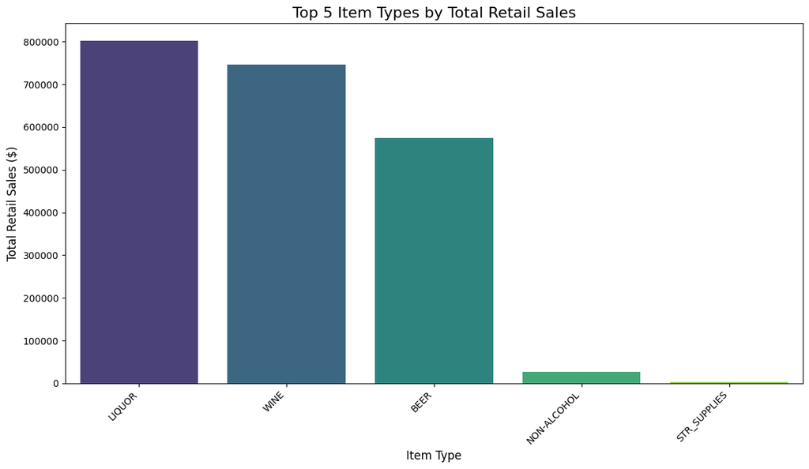

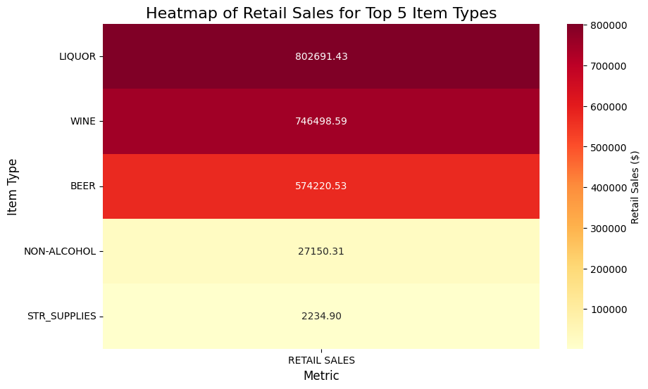

```python
# prompt: Customize Your Plots: Make sure your visualizations are clear and informative by:
# Adding appropriate titles
# Labeling axes also include step by step comments
# Using colors effectively (different colors for heat map)
# Adding legends when necessary

# Bar chart with customization
plt.figure(figsize=(12, 7)) # Adjust figure size for better readability

# Create a bar plot using seaborn
sns.barplot(x='ITEM TYPE', y='RETAIL SALES', data=top_5_items, palette='viridis')

# Add a title to the plot
plt.title('Top 5 Item Types by Total Retail Sales', fontsize=16)

# Add labels to the x and y axes
plt.xlabel('Item Type', fontsize=12) # Label for the x-axis (Item Type)
plt.ylabel('Total Retail Sales ($)', fontsize=12) # Label for the y-axis (Total Retail Sales)

# Rotate x-axis labels for better readability if they are long
plt.xticks(rotation=45, ha='right', fontsize=10) # Rotate labels and align them to the right

# Improve layout to prevent labels from overlapping
plt.tight_layout()

# Show the plot
plt.show()

# Heatmap with customization
plt.figure(figsize=(10, 6)) # Adjust figure size

# Create a heatmap using seaborn
sns.heatmap(heatmap_data, annot=True, fmt='.2f', cmap='YlOrRd', cbar_kws={'label': 'Retail Sales ($)'}) # Use a different color map and label the color bar

# Add a title to the heatmap
plt.title('Heatmap of Retail Sales for Top 5 Item Types', fontsize=16)

# Add labels to the axes (although for a simple heatmap like this, they might be less critical depending on layout)
plt.xlabel('Metric', fontsize=12) # Label for the x-axis (in this case, it's just 'Retail Sales')
plt.ylabel('Item Type', fontsize=12) # Label for the y-axis (Item Type)

# Show the plot
plt.show()
```

4. Analysis: Write 1-2 paragraphs discussing:
- Whether your research question can be answered with the available data
- What insights you discovered through your visualizations
- Any unexpected or interesting findings
- Limitations of your analysis
- Suggestions for further investigation

Please create a text cell below this cell to write your analysis.

Based on the provided data and visualizations, I can effectively answer the research question: What item types were the top 5 in retail sales. The bar chart and heatmap clearly illustrate the top 5 item types based on their aggregated retail sales. From these visualizations, it's evident that liquor is the highest-selling item type, followed by Wine and Beer. The difference in retail sales between the top item and the others appears to be moderate for the first three then a large drop on 4 and 5, suggesting a dominant performers in the market.

While the visualizations provide a clear answer to the primary question, this analysis has certain limitations. It focuses solely on the overall retail sales volume and doesn't account for profitability, which would require data on the cost of goods sold. Additionally, this analysis doesn't consider the time dimension; examining sales trends over time could reveal seasonality or growth patterns for these top items. Further investigation could involve analyzing the impact of wholesale sales on retail performance or exploring geographical variations in sales for these popular item types.

## NOTE: If you use a local dataset, you MUST submit the dataset along with your notebook to get credit.

- Download your notebook as CS110_Project7.ipynb
- Ensure all TODO tasks are completed
- Make sure your code runs without errors
- Include clear comments explaining your work
- Submit the notebook file

## Grading Criteria (4 points)

- Dataset Selection: Appropriate choice of dataset with sufficient complexity
- Inquiry Question: Clear, specific, and answerable with the chosen data
- Data Exploration: Proper use of pandas functions for initial analysis
- Visualizations: At least 2 clear, well-formatted, and relevant plots
- Analysis: Thoughtful interpretation of findings and answer to research question
- Code Quality: Clean, commented, and well-organized code

Remember: The goal is not just to create visualizations, but to use them to gain meaningful insights about your data. Think like a data scientist and let your curiosity guide your exploration!